# Scraping HTML data from the web

Mahbubul Majumder, PhD  
Oct 23, 2014

### Sources of data online

- Each web site is a source of data
- Three ways to obtain data from the web
  1. we already worked on how to get entire web site into `R` and look for useful information
  2. scraping data from HTML tables or other tags
  3. using API provided by respective data sources
- Web data could be structured or unstructured or semi-structured
  - plain texts are usually unstructured
  - HTML tables are usually structured
- Sources of data through API
  - twitter, Facebook or other social or professional media or blog
  - mostly unstructured, but there may be intrinsic structure
  - some times very useful and interesting

### Data in HTML documents

- Often we see data in HTML tables
  - sports or crimes or others statistics
- How would you get data from an HTML table
  - copy the data and paste in Excel (demonstration: get data from nfl.com)
  - Excel is very useful, every one should learn it
  - but it could be very tricky to handle large data table
  - manual operation is always risky
- Fortunately we can do it automatically using package `XML`

```r
# install.packages("XML")
library(XML)
```

### Scraping HTML tables

- First inspect the data by going to the HTML link
  - chrome has nice features to do that
  - write click on the page and select inspect element
  - can examine all the tags, attributes and values
- As you scroll your mouse over the elements it will highlight in the page
  - go to the respective table which contains the data
  - get the id for that table
- Demonstration with getting passing yards data
  - http://www.nfl.com/stats/player
  - select year 2012
  - select complete list of passing yards
  - notice there are multiple pages

### Inspecting HTML tables

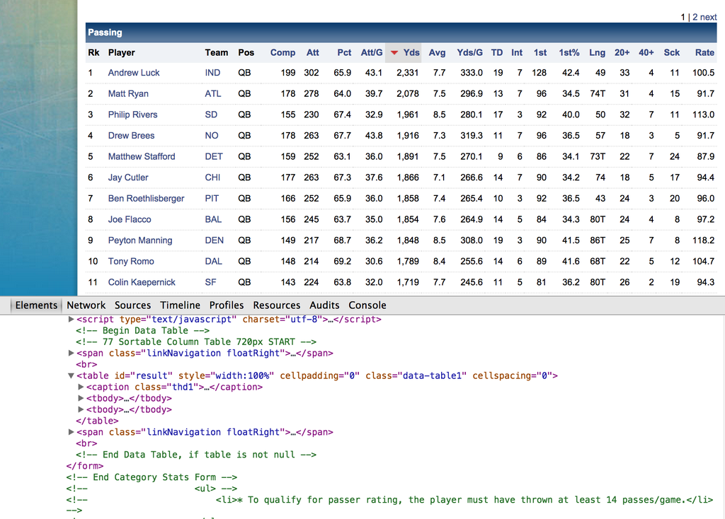

### Case Study: Gathering data from NFL web site

```r
u0 <- "http://www.nfl.com/stats/categorystats?tabSeq=0&"
u1 <- "season=2012&seasonType=PRE&experience=&Submit=Go&"
u2 <- "archive=true&conference=null&statisticCategory=PASSING&"

url1 <- paste(u0,u1,u2,"d-447263-p=1&qualified=false", sep="")
url2 <- paste(u0,u1,u2,"d-447263-p=2&qualified=false", sep="")
url3 <- paste(u0,u1,u2,"d-447263-p=3&qualified=false", sep="")

# Scan the table
tables1 <- readHTMLTable(url1)
tables2 <- readHTMLTable(url2)
tables3 <- readHTMLTable(url3)

# In HTML codes id="result" contains the desired data
bd1 <- tables1$result
bd2 <- tables2$result
bd3 <- tables3$result

# combine the multiple pages of data together
nflData <- rbind(bd1,bd2,bd3)
```

### Case Study: Gathering data from NFL web site

- Apply your knowledge to clean and shape the data for display

```r
names(nflData)
```

```
 [1] "Rk"      "Player"  "Team"    "Pos"     "\nComp"  "\nAtt"   "\nPct"
 [8] "\nAtt/G" "\nYds"   "\nAvg"   "\nYds/G" "\nTD"    "\nInt"   "\n1st"
[15] "\n1st%"  "\nLng"   "\n20+"   "\n40+"   "\nSck"   "\nRate"
```

```r
names(nflData) <- gsub("\n","",names(nflData))
is.factor(nflData$Rate)
```

```
[1] TRUE
```

```r
nflData$Rate = as.numeric(as.character(nflData$Rate))
# get top 15 players based on Rating
datPlot <- nflData[order(nflData$Rate,decreasing=T)[1:15],]
```

### Case Study: Gathering data from NFL web site

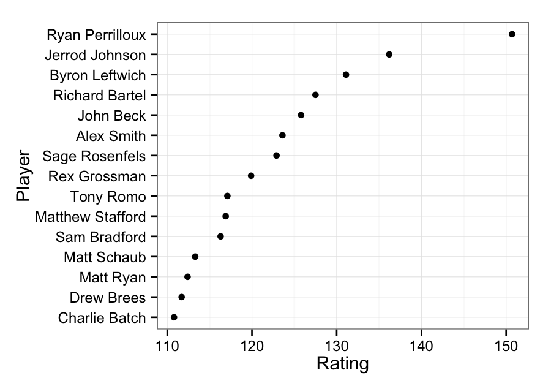

```r
ggplot(datPlot, aes(reorder(Player,Rate), Rate)) +
  geom_point(stat = "identity") + coord_flip() + theme_bw()+
  ylab("Rating") + xlab("Player")
```

### Gathering twitter data

- twitter provides API to obtain tweets information
- Use `R` package `twitteR` to extract and work with twitter data
  - you can search specific tweets by person, location, topic etc.
  - analyse re-tweets
  - install `twitteR` from `github` not `CRAN` what you usually do
- twitter data some times provides interesting information about current incidents
- Challenge is how to handle various languages and grammar or spelling
  - some times it is highly misleading to decide based on one language
  - in tweets many people don't care about spelling or mixing language

### Setting up twitter API

- First create a twitter account
  - create a new application from https://apps.twitter.com/
  - will provide you with API keys and secrets
- Now run the following codes from `R` (for details https://github.com/geoffjentry/twitteR/)

```r
#install.packages(c("devtools", "rjson", "bit64", "httr"))
library(devtools)
#install_github("twitteR", username="geoffjentry")
library(twitteR)

api_key <- "your api key"
api_secret <- "your api secret"
access_token <- "your access tocken"
access_token_secret <- "your access tocken secret"

setup_twitter_oauth(api_key,api_secret,access_token,
                    access_token_secret)
```

```
[1] "Using direct authentication"
```

### Case Study: Getting the tweets about data science

```r
dsTweet <- searchTwitter("data science")
dfTweet <- twListToDF(dsTweet)
tweetText <- dfTweet$text
head(tweetText)
```

```
[1] "RT @KirkDBorne: Get the 1-page R Survival Guides for #DataScientists: http://t.co/s1nfEdr7rx #abdsc #BigData #Analytics #Rstats http://t.co…"
[2] "RT @Steve_Burkett: #Football Scouting actually is a science not rocket science but does require advanced data analysis techniques to be suc…"
[3] "RT @Steve_Burkett: #Football Scouting actually is a science not rocket science but does require advanced data analysis techniques to be suc…"
[4] "RT @KirkDBorne: Get the 1-page R Survival Guides for #DataScientists: http://t.co/s1nfEdr7rx #abdsc #BigData #Analytics #Rstats http://t.co…"
[5] "Reminder for Today's  Event http://t.co/rc0BYMMFkd"
[6] "RT @Steve_Burkett: #Football Scouting actually is a science not rocket science but does require advanced data analysis techniques to be suc…"
```

### Case Study: tweets of Dr. Sanjay Gupta

```r
user <- getUser("drsanjaygupta")
sanjay <- userTimeline(user, n=500)
snDf <- twListToDF(sanjay)
snText <- snDf$text
library(stringr)
snWords <- str_extract_all(snText, '(\\w+)')
head(snWords)
```

```
[[1]]
[1] "MsNikki214" "I"          "really"     "appreciate" "that"
[6] "Thank"      "you"

[[2]]
 [1] "NY"         "amp"        "NJ"         "quarantine" "rule"
 [6] "will"       "cover"      "anyone"     "not"        "just"
[11] "health"     "care"       "workers"    "known"      "to"
[16] "have"       "had"        "contact"    "with"       "an"
[21] "Ebola"      "patient"

[[3]]
 [1] "NY"          "amp"         "NJ"          "health"      "departments"
 [6] "order"       "21"          "day"         "quarantine"  "for"
[11] "all"         "returning"   "health"      "care"        "workers"
[16] "who"         "ve"          "had"         "direct"      "contact"
[21] "with"        "Ebola"       "patients"

[[4]]
 [1] "here"       "s"          "why"        "you"        "don"
 [6] "t"          "need"       "to"         "worry"      "about"
[11] "ebola"      "even"       "though"     "there"      "s"
[16] "now"        "another"    "case"       "in"         "the"
[21] "US"         "http"       "t"          "co"         "bUx9I7T3Ta"

[[5]]
 [1] "Here"       "is"         "a"          "good"       "time"
 [6] "line"       "for"        "Dr"         "Craig"      "Spencer"
[11] "Ebola"      "ebol"       "http"       "t"          "co"
[16] "E5Sks6ylWb"

[[6]]
 [1] "Admin"       "official"    "just"        "told"        "me"
 [6] "considering" "mandatory"   "quarantine"  "for"         "healthcare"
[11] "workers"     "returning"   "from"        "W"           "Africa"
[16] "We"          "understand"  "public"      "fear"
```

### Case Study: Hashtags in Dr. Sanjay Gupta's tweets

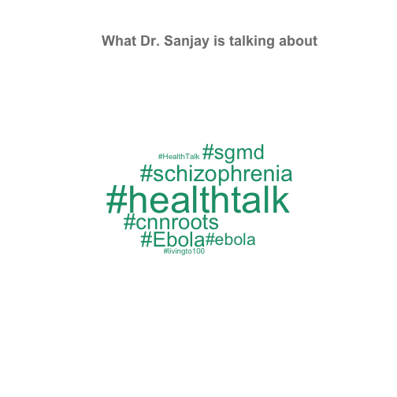

```r
snHashtags = str_extract_all(snDf$text, "#\\w+")
freq <- table(unlist(snHashtags))

library(wordcloud)
wordcloud(names(freq), freq, random.order=FALSE, colors="#1B9E77")
title("\n\nWhat Dr. Sanjay is talking about",
    cex.main=1.5, col.main="gray50")
```

### Sources of tweets

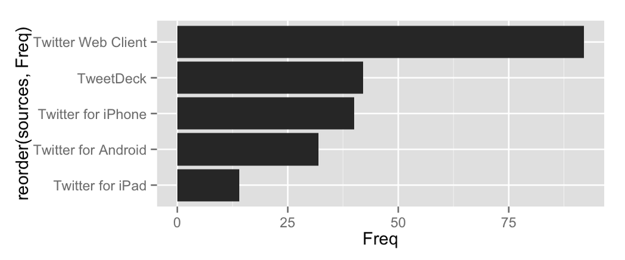

```r
r_tweets <- searchTwitter("#rstats", n=300)
sources <- sapply(r_tweets, function(x) x$getStatusSource())
sources <- gsub("</a>", "", sources)
sources <- strsplit(sources, ">")
sources <- sapply(sources, function(x) ifelse(length(x) > 1, x[2], x[1]))
source_table = table(sources)
df <- data.frame(names(source_table),source_table)
ggplot(df[df$Freq>8,], aes(reorder(sources,Freq),Freq)) +
  geom_bar(stat="identity") + coord_flip()
```

### Reading assignment and references

- For details about setting up `twitteR` package in `R`  
  https://github.com/geoffjentry/twitteR/
- For examples of `twitteR` functions and what this package can deliver visit  
  http://geoffjentry.hexdump.org/twitteR.pdf